# Feature Engineering

Great! Now we have setup methodology for checking the performance of the model so we are completely ready to start improving it.

This was the very basic glm model we fit in the last lesson.

```r
model1 <- glm(data = dt_pol_w_claims,
              formula = Burning_Cost ~ Veh_type2,
              family = Gamma())
```

We trained it on full dataset, which does not go with our methodology. Lets fit it on **training** part of data.

```r
# fitting model only on training dataset
model1a <- glm(data = train,
              formula = Burning_Cost ~ Veh_type2,
              family = Gamma())
```

```r
# lets make prediciton on validation dataset and evaluate model
prediction <- predict(model1a, val, type = "response")
```

```r
mse(prediction, val$Burning_Cost)
```

```
## [1] 286.2723
```

Okay, we know, that by metric we are using to improve model it means decreasing MSE metric. Now we will try different approaches to achieve it.

List of a few feature engineering approaches:

1. Add new variable
   - More information you bring model is becoming much more accurate as it is able to catch much more various situations
2. Remove some variable
   - Althought adding new variable brings new information to the model, it brings also the noise. You need to find a balance between this. Model should be robust and not overfitted.
3. Grouping of Categorical variable
4. Interaction
5. Normalization
6. Credibility Weighting
7. Outlier resolution
8. Capping strategy to keep only trending part of the variable
9. Transformation of variable (polynomial, log, exp, …)

#### Add a new variable

```r
model2 <- glm(data = train,
              formula = Burning_Cost ~ Veh_type2 + Construct_year,
              family = Gamma())
summary(model2)
```

```
##
## Call:
## glm(formula = Burning_Cost ~ Veh_type2 + Construct_year, family = Gamma(),
##     data = train)
##
## Deviance Residuals:
##     Min       1Q   Median       3Q      Max
## -3.1655  -1.1606  -0.5735   0.1003   4.0374
##
## Coefficients:
##                     Estimate Std. Error t value Pr(>|t|)
## (Intercept)         3.799355   2.458321   1.546   0.1224
## Veh_type2MOTORBIKE -0.034862   0.029550  -1.180   0.2383
## Veh_type2PICKUP    -0.017070   0.008708  -1.960   0.0501 .
## Veh_type2TRUCK     -0.067186   0.010340  -6.498 1.08e-10 ***
## Construct_year     -0.001837   0.001223  -1.502   0.1333
## ---
## Signif. codes:  0 '***' 0.001 '**' 0.01 '*' 0.05 '.' 0.1 ' ' 1
##
## (Dispersion parameter for Gamma family taken to be 1.96378)
##
##     Null deviance: 2649.3  on 1654  degrees of freedom
## Residual deviance: 2595.3  on 1650  degrees of freedom
## AIC: 10834
##
## Number of Fisher Scoring iterations: 7
```

```r
mse(predict(model2, train, type = "response"), train$Burning_Cost)
```

```
## [1] 195.3979
```

```r
mse(predict(model2, val, type = "response"), val$Burning_Cost)
```

```
## [1] 288.1473
```

#### Remove some variable

Lets add some more variables, so you can see how overfitting looks like.

```r
model3 <- glm(data = train,
              formula = Burning_Cost ~ Customer_Type +Time_on_book + D_age  + Construct_year + Capacity + Nr_of_seats + BonusMalus + D_ZIP + Nr_payments + Sum_insured,
              family = Gamma())
summary(model3)
```

```
##
## Call:
## glm(formula = Burning_Cost ~ Customer_Type + Time_on_book + D_age +
##     Construct_year + Capacity + Nr_of_seats + BonusMalus + D_ZIP +
##     Nr_payments + Sum_insured, family = Gamma(), data = train)
##
## Deviance Residuals:
##     Min       1Q   Median       3Q      Max
## -3.1697  -1.1582  -0.5805   0.1192   3.9277
##
## Coefficients:
##                  Estimate Std. Error t value Pr(>|t|)
## (Intercept)     2.084e-01  2.818e+00   0.074 0.941054
## Customer_TypeS -1.494e-03  1.154e-02  -0.130 0.896968
## Time_on_book    2.153e-03  1.433e-03   1.502 0.133294
## D_age          -2.014e-04  3.533e-04  -0.570 0.568596
## Construct_year -5.647e-05  1.401e-03  -0.040 0.967854
## Capacity       -5.169e-06  1.467e-06  -3.523 0.000439 ***
## Nr_of_seats     3.661e-03  2.139e-03   1.711 0.087204 .
## BonusMalus     -1.052e-03  8.172e-04  -1.287 0.198119
## D_ZIP           3.640e-06  1.708e-06   2.131 0.033227 *
## Nr_payments     7.661e-04  3.301e-03   0.232 0.816485
## Sum_insured    -5.282e-07  2.732e-07  -1.933 0.053391 .
## ---
## Signif. codes:  0 '***' 0.001 '**' 0.01 '*' 0.05 '.' 0.1 ' ' 1
##
## (Dispersion parameter for Gamma family taken to be 1.958457)
##
##     Null deviance: 2639.5  on 1649  degrees of freedom
## Residual deviance: 2573.0  on 1639  degrees of freedom
##   (5 observations deleted due to missingness)
## AIC: 10792
##
## Number of Fisher Scoring iterations: 7
```

```r
mse(predict(model3, train, type = "response"), train$Burning_Cost)
```

```
## [1] 190.7756
```

```r
mse(predict(model3, val, type = "response"), val$Burning_Cost)
```

```
## [1] 293.435
```

You can see, the metric for modeling part decreased pretty well, but when we try to bring this new model to new data, meaning for validation dataset, then it is even worse than `model2`, where there are only two variables.

#### Capping Strategy and Trend Exploration

Lets go back to `model2` and see how the trend of our prediction looks like for individual variables. It is similar type of analysis as One-Way Analysis we performed on previous Lesson. Only thing we add here is trend for prediciton vs. variable we are trying to explore.

I created function where you can define model, exploratory variable, target and our current prediction.

```
##   group_var weight_sum weight_sum_pct        line      mean
## 1       CAR       1339     80.9063444 actual_mean  9.346494
## 2 MOTORBIKE         11      0.6646526 actual_mean 14.461301
## 3    PICKUP        267     16.1329305 actual_mean 11.145892
## 4     TRUCK         38      2.2960725 actual_mean 23.697335
## 5       CAR       1339     80.9063444 fitted_mean  9.346494
## 6 MOTORBIKE         11      0.6646526 fitted_mean 14.461301
## 7    PICKUP        267     16.1329305 fitted_mean 11.145892
## 8     TRUCK         38      2.2960725 fitted_mean 23.697335
```

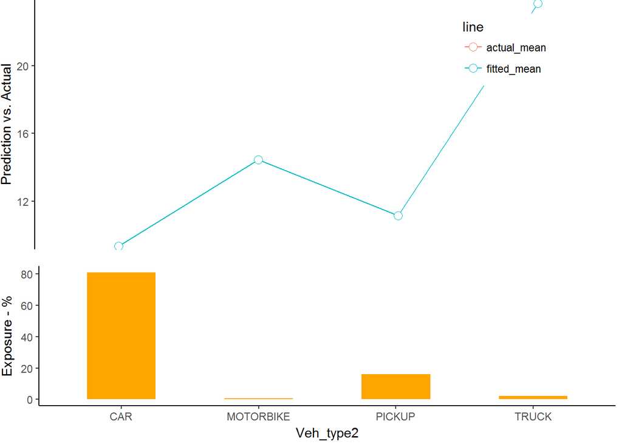

```r
source("Support/emb_chart.R")
emblem_graph(
  dt.frm = train %>% cbind(data.frame(pred = predict(model2, train, type = "response"))),
  x_var =  "Veh_type2",
  target = "Burning_Cost",
  prediction =  "pred"
  )
```

Very nice fit. However it might be caused we have only two variables in the model. Remember, althought you can observe very nice trend in this type of chart, it might be caused also by other variable as prediction always contain trend from all variables included in the model.

Lets look to another variable fitted in the model.

```
##    group_var weight_sum weight_sum_pct        line      mean
## 1       1989          1     0.06042296 actual_mean  3.661111
## 2       1996          1     0.06042296 actual_mean  7.250230
## 3       1997          2     0.12084592 actual_mean 49.991485
## 4       1999          1     0.06042296 actual_mean  1.660835
## 5       2001          5     0.30211480 actual_mean  3.472258
## 6       2002          9     0.54380665 actual_mean  7.297106
## 7       2003         15     0.90634441 actual_mean  9.678279
## 8       2004         18     1.08761329 actual_mean 14.564518
## 9       2005         24     1.45015106 actual_mean  5.544611
## 10      2006         46     2.77945619 actual_mean  7.772299
## 11      2007        116     7.00906344 actual_mean  8.875707
## 12      2008        142     8.58006042 actual_mean  9.867997
## 13      2009        215    12.99093656 actual_mean 11.677667
## 14      2010        253    15.28700906 actual_mean  9.069100
```

[output cut: 24 more lines]

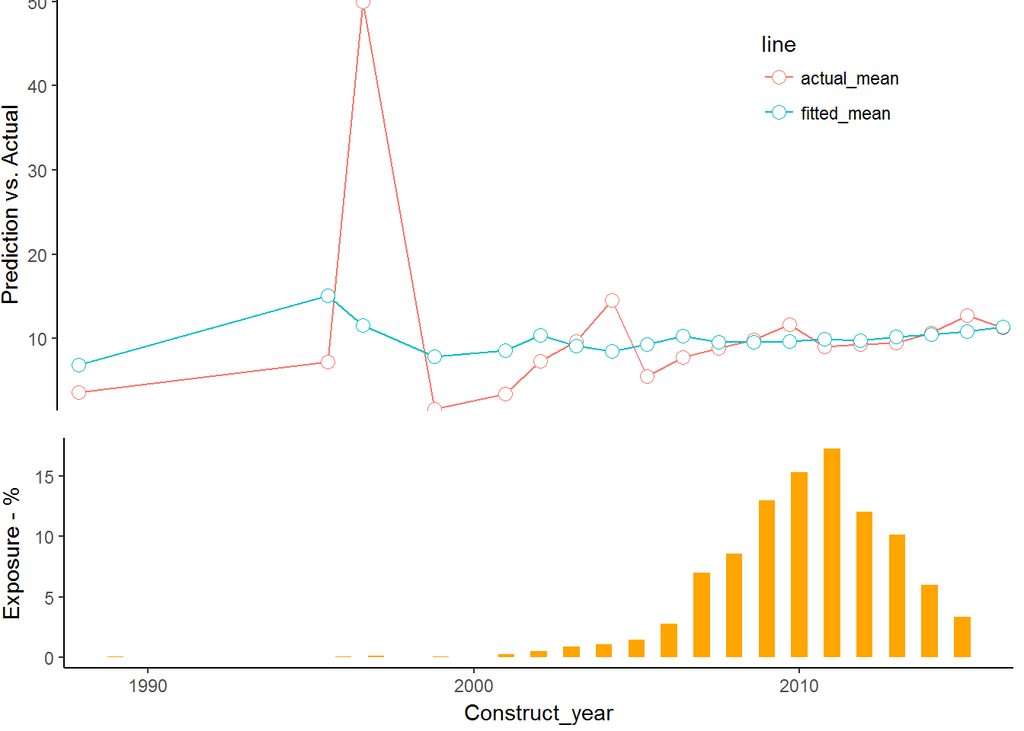

```r
emblem_graph(
  dt.frm = train %>% cbind(data.frame(pred = predict(model2, train, type = "response"))),
  x_var =  "Construct_year",
  target = "Burning_Cost",
  prediction =  "pred"
  )
```

There is quite a lot of noise in early `Construction Year`s due to so little observations. You can see this is negatively influencing the trend.

To correct this behaviour we can **cap** variable in its start left lets say in `Construction Year` 2007 to create bigger bin in term of no. of observation.

```r
train <- train %>%
  mutate(Construct_year = ifelse(Construct_year <= 2007, 2007, Construct_year))

model4 <- glm(data = train,
              formula = Burning_Cost ~ Veh_type2 + Construct_year,
              family = Gamma())
summary(model4)
```

```
##
## Call:
## glm(formula = Burning_Cost ~ Veh_type2 + Construct_year, family = Gamma(),
##     data = train)
##
## Deviance Residuals:
##     Min       1Q   Median       3Q      Max
## -3.1635  -1.1594  -0.5706   0.1011   3.9716
##
## Coefficients:
##                     Estimate Std. Error t value Pr(>|t|)
## (Intercept)         5.063668   2.896812   1.748   0.0806 .
## Veh_type2MOTORBIKE -0.034287   0.029442  -1.165   0.2444
## Veh_type2PICKUP    -0.017113   0.008672  -1.973   0.0486 *
## Veh_type2TRUCK     -0.066430   0.010268  -6.469 1.29e-10 ***
## Construct_year     -0.002465   0.001441  -1.711   0.0872 .
## ---
## Signif. codes:  0 '***' 0.001 '**' 0.01 '*' 0.05 '.' 0.1 ' ' 1
##
## (Dispersion parameter for Gamma family taken to be 1.950013)
##
##     Null deviance: 2649.3  on 1654  degrees of freedom
## Residual deviance: 2594.2  on 1650  degrees of freedom
## AIC: 10833
##
## Number of Fisher Scoring iterations: 7
```

```r
mse(predict(model4, train, type = "response"), train$Burning_Cost)
```

```
## [1] 195.4841
```

```r
mse(predict(model4, val, type = "response"), val$Burning_Cost)
```

```
## [1] 288.5814
```

Lets check the trend again after we fitted a new model.

```
##    group_var weight_sum weight_sum_pct        line      mean
## 1       2007        238      14.380665 actual_mean  8.920606
## 2       2008        142       8.580060 actual_mean  9.867997
## 3       2009        215      12.990937 actual_mean 11.677667
## 4       2010        253      15.287009 actual_mean  9.069100
## 5       2011        285      17.220544 actual_mean  9.287461
## 6       2012        199      12.024169 actual_mean  9.487274
## 7       2013        168      10.151057 actual_mean 10.700015
## 8       2014         99       5.981873 actual_mean 12.708380
## 9       2015         56       3.383686 actual_mean 11.255623
## 10      2007        238      14.380665 fitted_mean  9.615426
## 11      2008        142       8.580060 fitted_mean  9.354944
## 12      2009        215      12.990937 fitted_mean  9.578907
## 13      2010        253      15.287009 fitted_mean  9.896821
## 14      2011        285      17.220544 fitted_mean  9.797966
## 15      2012        199      12.024169 fitted_mean 10.239417
## 16      2013        168      10.151057 fitted_mean 10.625719
## 17      2014         99       5.981873 fitted_mean 11.105660
## 18      2015         56       3.383686 fitted_mean 11.707181
```

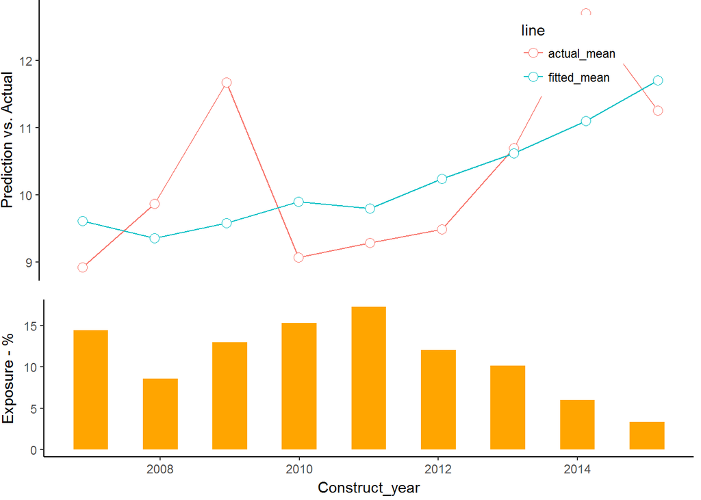

```r
emblem_graph(
  dt.frm = train %>% cbind(data.frame(pred = predict(model4, train, type = "response"))),
  x_var =  "Construct_year",
  target = "Burning_Cost",
  prediction =  "pred"
  )
```

#### Category Grouping

Have you observed that variable `Veh_type2` and theirs categories `CAR` and `PICKUP` has their actual mean similar?

```r
train <- train %>% mutate(Veh_type2 = ifelse(as.character(Veh_type2) == 'PICKUP' | as.character(Veh_type2) == 'CAR', 'CAR & PICKUP', as.character(Veh_type2)))
model5 <- glm(data = train,
              formula = Burning_Cost ~ Veh_type2 + Construct_year ,
              family = Gamma())
summary(model5)
```

```
##
## Call:
## glm(formula = Burning_Cost ~ Veh_type2 + Construct_year, family = Gamma(),
##     data = train)
##
## Deviance Residuals:
##     Min       1Q   Median       3Q      Max
## -3.1731  -1.1676  -0.5659   0.0892   3.8995
##
## Coefficients:
##                     Estimate Std. Error t value Pr(>|t|)
## (Intercept)         5.119354   2.901654   1.764   0.0779 .
## Veh_type2MOTORBIKE -0.030955   0.029360  -1.054   0.2919
## Veh_type2TRUCK     -0.063146   0.010081  -6.264 4.78e-10 ***
## Construct_year     -0.002495   0.001443  -1.729   0.0841 .
## ---
## Signif. codes:  0 '***' 0.001 '**' 0.01 '*' 0.05 '.' 0.1 ' ' 1
##
## (Dispersion parameter for Gamma family taken to be 1.947439)
##
##     Null deviance: 2649.3  on 1654  degrees of freedom
## Residual deviance: 2601.3  on 1651  degrees of freedom
## AIC: 10837
##
## Number of Fisher Scoring iterations: 7
```

```r
mse(predict(model5, train, type = "response"), train$Burning_Cost)
```

```
## [1] 195.8734
```

```r
mse(predict(model5, val %>% mutate(
Veh_type2 = ifelse(
as.character(Veh_type2) == 'PICKUP' | as.character(Veh_type2) == 'CAR',
'CAR & PICKUP',
as.character(Veh_type2)
)
), type = "response"),
val$Burning_Cost)
```

```
## [1] 289.1521
```

```
##      group_var weight_sum weight_sum_pct        line      mean
## 1 CAR & PICKUP       1606     97.0392749 actual_mean  9.645647
## 2    MOTORBIKE         11      0.6646526 actual_mean 14.461301
## 3        TRUCK         38      2.2960725 actual_mean 23.697335
## 4 CAR & PICKUP       1606     97.0392749 fitted_mean  9.645647
## 5    MOTORBIKE         11      0.6646526 fitted_mean 14.461301
## 6        TRUCK         38      2.2960725 fitted_mean 23.697335
```

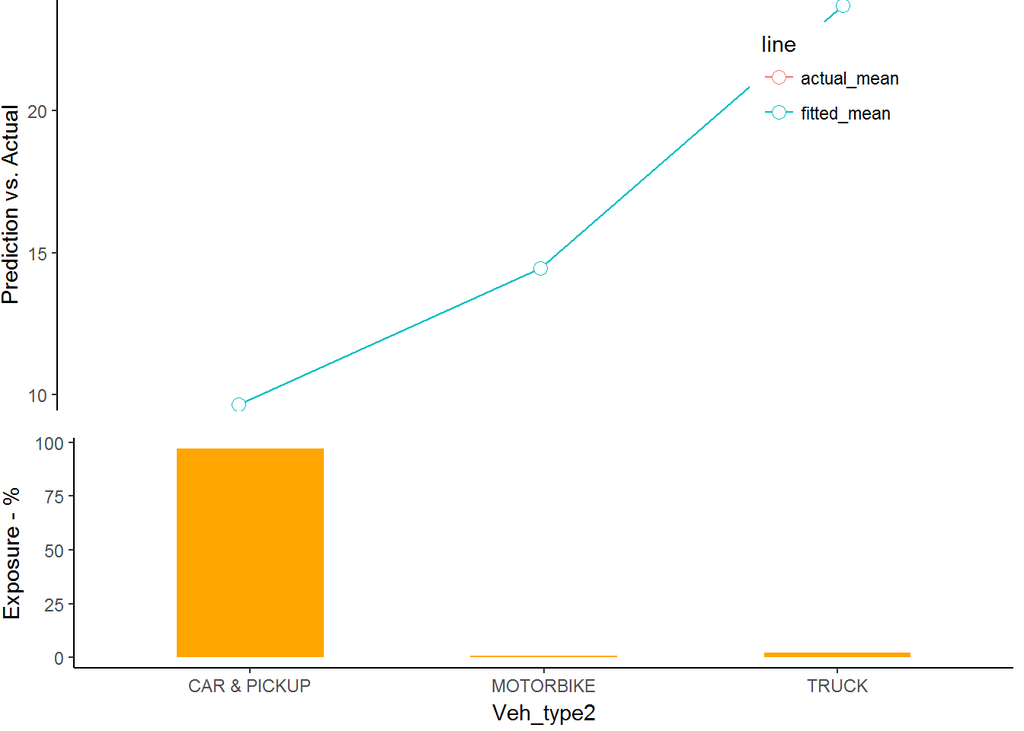

```r
emblem_graph(
  dt.frm = train %>% cbind(data.frame(pred = predict(model5, train, type = "response"))),
  x_var =  "Veh_type2",
  target = "Burning_Cost",
  prediction =  "pred"
  )
```